# Darren Hunt

PHYS 434AA

10-15-2020

HW 2

```python
%matplotlib inline
import numpy as np
import matplotlib
import matplotlib.pyplot as plt
import scipy
from scipy import stats

plt.rcParams["figure.figsize"] = (21,7)
```

# 1

Which is more probable when rolling 2 six-sided dice: rolling snake eyes (two ones) or rolling sevens (dice sum to seven)? What is the ratio of the probabilities?

The first scenario is asking for the probability of dice #1 rolling a one AND dice #2 rolling a one. P(A and B) = P(A)P(B)

Each die has 6 sides, so the probability of rolling a one on either die alone is 1/6. There is only one possible combination to achieve this outcome.

```python
# P of rolling 2 ones
P_2_ones = (1/6)*(1/6)
print("Probability of rolling 2 ones : " + str("{0:.5f}".format(P_2_ones)))
```

```
Probability of rolling 2 ones : 0.02778
```

The probabilty of rolling a sum of seven has different combinations to achieve the same sum, so there are more possible chances for this outcome to occur. The (unique) combinations of the two dice are:

1 and 6; 2 and 5; 3 and 4.

And since each of these combinations can occur twice,

6 and 1; 5 and 2; 4 and 3,

there are a total of 6 possible combinations leading to the same outcome sum of 7. Therefore, the calculation for this probability takes the probabilities of getting *N* as a value on a 6 sided die (always 1/6 for equal chances to roll), times that again (for the second die) times 6 (for the 6 different combinations possible).

```python
# P of rolling sum of 7
P_sum_7 = (1/6)*(1/6)*6
print("Probability of rolling sum of 7 : " + str("{0:.5f}".format(P_sum_7)))
```

```
Probability of rolling sum of 7 : 0.16667
```

```python
# ratio of the probabilities
ratio_dice = P_sum_7 / P_2_ones
print("Ratio of probabilities : " + str("{0:.2f}".format(ratio_dice)))
```

```
Ratio of probabilities : 6.00
```

# 2

Show how to use the convolution operator to determine the probability of the **sum** of 2 six sided dice. Do both analytically (math & counting) and numerically (computer program). Beware the implicit definition of the values (x-axis on histogram).

https://numpy.org/doc/stable/reference/generated/numpy.convolve.html

**Using the convolution operator:**

```python
# use convolution operator: use np.convolve(a, v)
import itertools  # to quickly print all possible sums for the two dice

A = np.ndarray.flatten(np.full((1,6), 1/6, dtype=float))  # fill and flatten array of values of 1/6, for each side of the die
sides = np.arange(1,7,1)  # possible values on a die

P_AB_sum = np.convolve(A, A)  # probabilities for each possible sum of 2 six-sided dice
tot = {sum(i) for i in itertools.combinations_with_replacement(sides, 2)}  # compute all possible sums from the two dice

print(P_AB_sum)  # sorted probabilities
print(tot)  # sorted possible sums
```

```
[0.02777778 0.05555556 0.08333333 0.11111111 0.13888889 0.16666667
 0.13888889 0.11111111 0.08333333 0.05555556 0.02777778]
{2, 3, 4, 5, 6, 7, 8, 9, 10, 11, 12}
```

**By math/counting:**

Following the logic from problem #1 above, each side of each die has a 1/6 probability of being rolled. The probability for both A and B to be rolled is still P(A+B) = P(A)P(B) * n, where I am multipling by n if there are multiple ways the same sum can be achieved, since this raises the probability of rolling a certain sum.

P(sum=2) = 1,1 = 1 combination

P(sum=3) = 1,2; 2,1 = 2 combinations

P(sum=4) = 1,3; 2,2; 3,1 = 3 combinations

P(sum=5) = 1,4; 2,3; 3,2; 4,1 = 4 combinations

P(sum=6) = 1,5; 2,4; 3,3; 4,2; 5,1 = 5 combinations

P(sum=7) = 1,6; 2,5; 3,4; 4,3; 5,2; 6,1 = 6 combinations

P(sum=8) = 2,6; 3,5; 4,4; 5,3; 6,2 = 5 combinations

P(sum=9) = 3,6; 4,5; 5,4; 6,3 = 4 combinations

P(sum=10) = 4,6; 5,5; 6,4 = 3 combinations

P(sum=11) = 5,6; 6,5 = 2 combinations

P(sum=12) = 6,6 = 1 combination

```python
# finding probabilities by counting

sums = np.arange(2,13,1)  # all the possible sums
combos = [1,2,3,4,5,6,5,4,3,2,1]  # all the possible combos, as determined in the previous cell
prbs = np.ndarray.flatten(np.full((1,11), 1/6, dtype=float))  # all single values have equal chance of being rolled at 1/6

all_prbs = prbs * prbs * combos  # 1/6 * 1/6 * the number of possible times to roll that sum with different combinations
print(all_prbs)  # all probabilities, sorted in order of the sums increasing (from 2 to 12)
print(sums)
```

```
[0.02777778 0.05555556 0.08333333 0.11111111 0.13888889 0.16666667
 0.13888889 0.11111111 0.08333333 0.05555556 0.02777778]
[ 2  3  4  5  6  7  8  9 10 11 12]
```

The answers using these two methods are the same. The convolution operator took an array of dimensions (1,6) filled with the same value of 1/6 to represent the probabilities of each side of a single die; it took this same array twice to represent the two equal dice, and returned an array of the probabilities of all possible sums. I also created an array that calculated all possible sums when rolling two dice (as opposed to hand counting these, though that operation is simple). In the second method, I hand counted all possible sums and corresponding combinations when rolling two dice. To calculate without using the built in numpy convolution operator, I multiplied the array filled with 1/6 probabilities by itself (to represent both dice), then by another array filled with the different combinations possible for each sum. This was the same math, but with everything hand counted and filled in manually. Comparing the final arrays from either method show the same answers.

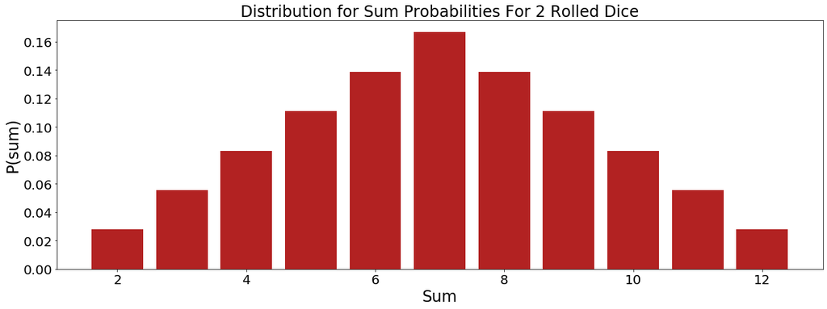

```python
# graph of the probabilities
fig, ax = plt.subplots(1, 1)
ax.set_title("Distribution for Sum Probabilities For 2 Rolled Dice", fontsize=24)
ax.set_xlabel("Sum", fontsize=24)
ax.set_ylabel("P(sum)", fontsize=24)
ax.tick_params(labelsize=20)

ax.bar(sums, all_prbs, color='firebrick')
plt.show()
```

# 3

Calculate the mean and the variance of the distribution in problem.

https://www.mathsisfun.com/data/random-variables-mean-variance.html

```python
probabilities = P_AB_sum
sums = sums  # just reuse the same values from above

mean = sum(sums * probabilities)  # this is the average, or expected, sum value (x-axis)
print("Mean sum = " + str(mean))
```

```
Mean sum = 7.0
```

```python
variance = sum((sums**2) * probabilities) - (mean**2)
print("Variance = " + str("{0:.2f}".format(variance)))
```

```
Variance = 5.83
```

The mean of the probability distribution is the mean of the expected values, not the mean of the probabilities. Our expected values are the possible sum outcomes of rolling two dice (stored in the array sums above). To find the mean, I multiplied the possible sum times its corresponding probability, then summed up these results. The variance followed a statistical formula for variance of a probability distribution and describes generally how far out the distribution spreads from the mean--if the expected value is about 7, our most probable outcome, it makes sense the distribution will spread about 5 in either direction.

# 4

Repeat 2, and graph the **average** of 10 dice. Is this is a Gaussian distribution? Explain in depth.

```python
# a function to convolve the rolled dice probabilities N given times

def average_dice(p_dice, N):
    # parameter dice: array of probabilities for each side of the die
    # parameter N: integer number of times to convolve
    avg = p_dice
    for i in range(N):
        avg = np.convolve(p_dice,avg)
    vals = np.linspace(1,6,len(avg))

    # for corresponding Gaussian
    mean = sum(vals * avg)
    std = np.sqrt(sum((vals ** 2) * avg) - (mean ** 2))
    return vals, avg, mean, std
```

```python
dice = np.ndarray.flatten(np.full((1,6), 1/6, dtype=float))  # same as from problem 1
avg10 = average_dice(dice, 10)
print(avg10[0])  # possible averages for ten rolled dice
print(avg10[1])  # corresponding probabilities
```

```
[1.         1.09090909 1.18181818 1.27272727 1.36363636 1.45454545
 1.54545455 1.63636364 1.72727273 1.81818182 1.90909091 2.
 2.09090909 2.18181818 2.27272727 2.36363636 2.45454545 2.54545455
 2.63636364 2.72727273 2.81818182 2.90909091 3.         3.09090909
 3.18181818 3.27272727 3.36363636 3.45454545 3.54545455 3.63636364
 3.72727273 3.81818182 3.90909091 4.         4.09090909 4.18181818
 4.27272727 4.36363636 4.45454545 4.54545455 4.63636364 4.72727273
 4.81818182 4.90909091 5.         5.09090909 5.18181818 5.27272727
 5.36363636 5.45454545 5.54545455 5.63636364 5.72727273 5.81818182
 5.90909091 6.        ]
[2.75636195e-09 3.03199814e-08 1.81919889e-07 7.88319517e-07
 2.75911831e-06 8.27735493e-06 2.20426265e-05 5.32722074e-05
 1.18611767e-04 2.45955689e-04 4.78904107e-04 8.81162057e-04
 1.53973962e-03 2.56546459e-03 4.08919526e-03 6.25234401e-03
 9.19101725e-03 1.30143669e-02 1.77793036e-02 2.34652097e-02
 2.99533825e-02 3.70163009e-02 4.43211149e-02 5.14496733e-02
 5.79345109e-02 6.33070903e-02 6.71518156e-02 6.91574824e-02
 6.91574824e-02 6.71518156e-02 6.33070903e-02 5.79345109e-02
 5.14496733e-02 4.43211149e-02 3.70163009e-02 2.99533825e-02
 2.34652097e-02 1.77793036e-02 1.30143669e-02 9.19101725e-03
 6.25234401e-03 4.08919526e-03 2.56546459e-03 1.53973962e-03
 8.81162057e-04 4.78904107e-04 2.45955689e-04 1.18611767e-04
 5.32722074e-05 2.20426265e-05 8.27735493e-06 2.75911831e-06
 7.88319517e-07 1.81919889e-07 3.03199814e-08 2.75636195e-09]
```

```python
avg200 = average_dice(dice,200)
```

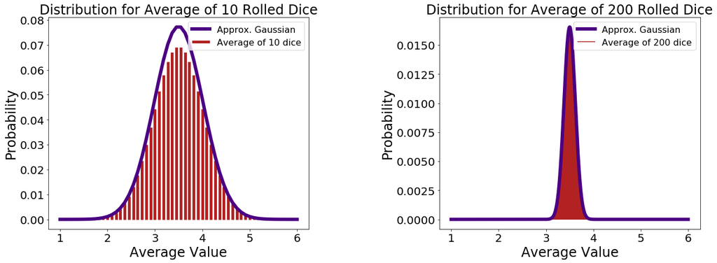

```python
# graph the average of 10 dice

fig, (ax1, ax2) = plt.subplots(1, 2, gridspec_kw={'wspace': 0.5})
ax1.set_title("Distribution for Average of 10 Rolled Dice", fontsize=24)
ax2.set_title("Distribution for Average of 200 Rolled Dice", fontsize=24)
ax1.set_xlabel("Average Value", fontsize=24), ax2.set_xlabel("Average Value", fontsize=24)
ax1.set_ylabel("Probability", fontsize=24), ax2.set_ylabel("Probability", fontsize=24)
ax1.tick_params(labelsize=20), ax2.tick_params(labelsize=20)

ax1.vlines(avg10[0],avg10[1], 0, color='firebrick', linewidth=5, label='Average of 10 dice')
ax1.plot(avg10[0], stats.norm.pdf(avg10[0], avg10[2], avg10[3]) / 10, linewidth='6', color='indigo', label='Approx. Gaussian')
ax1.legend(fontsize=16, loc='best')

ax2.vlines(avg200[0],avg200[1], 0, color='firebrick', label='Average of 200 dice')
ax2.plot(avg200[0], stats.norm.pdf(avg200[0], avg200[2], avg200[3]) / 200, linewidth='6', color='indigo', label='Approx. Gaussian')
ax2.legend(fontsize=16, loc='best')

plt.show()
```

# 5

Show that the sum and average of an initially Gaussian distribution is also a Gaussian (can be analytic or numerical). How does the standard deviation of the resulting sum or average Guassian change? This is a hugely important result. Explore what this means for integrating a signal over time.

To do this, we need to start with a Gaussian distribution of data. Additionally, a semilog plot will help determine the true Gaussian nature, as it should appear to be a parabola for semilog axes.

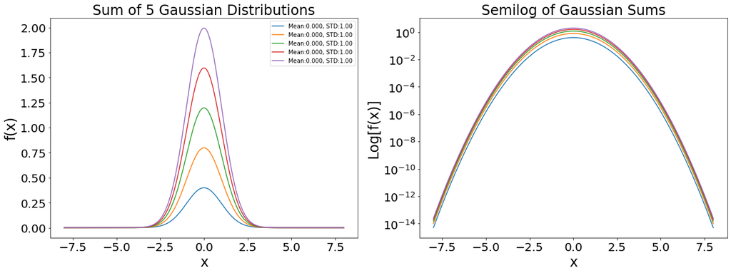

```python
# sums
fig, (ax1, ax2) = plt.subplots(1, 2)
ax1.set_title("Sum of 5 Gaussian Distributions", fontsize=24), ax2.set_title("Semilog of Gaussian Sums", fontsize=24)
ax1.set_xlabel("x", fontsize=24), ax2.set_xlabel("x", fontsize=24)
ax1.set_ylabel("f(x)", fontsize=24), ax2.set_ylabel("Log[f(x)]", fontsize=24)
ax1.tick_params(labelsize=20), ax2.tick_params(labelsize=20)

x = np.linspace(-8,8,1000)
g = stats.norm.pdf(x)
for i in range(5):
    gaussian_sums = g + g*i
    val = np.linspace(-8,8,len(gaussian_sums))
    mean = stats.norm.mean(gaussian_sums[i])
    std = stats.norm.std(gaussian_sums[i])
    ax1.plot(val, gaussian_sums, label="Mean:"+str("{0:.3f}".format(mean)) + ", STD:"+ str("{0:.2f}".format(std)))
    ax2.semilogy(val,gaussian_sums)

ax1.legend()
plt.show()
```

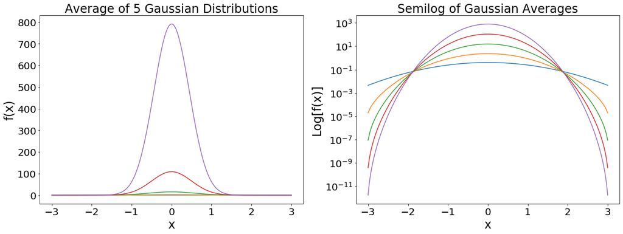

```python
# averages
fig, (ax1, ax2) = plt.subplots(1, 2)
ax1.set_title("Average of 5 Gaussian Distributions", fontsize=24), ax2.set_title("Semilog of Gaussian Averages", fontsize=24)
ax1.set_xlabel("x", fontsize=24), ax2.set_xlabel("x", fontsize=24)
ax1.set_ylabel("f(x)", fontsize=24), ax2.set_ylabel("Log[f(x)]", fontsize=24)
ax1.tick_params(labelsize=20), ax2.tick_params(labelsize=20)

x = np.linspace(-3,3,50)
g = stats.norm.pdf(x)

g1 = np.convolve(g,g)
g2 = np.convolve(g1,g)
g3 = np.convolve(g2,g)
g4 = np.convolve(g3,g)

gg = [g,g1,g2,g3,g4]

for i in range(len(gg)):
    ax1.plot(np.linspace(-3,3,len(gg[i])), gg[i])
    ax2.semilogy(np.linspace(-3,3,len(gg[i])), gg[i])

plt.show()
```

As we sum together distributions which are already Gaussian, the standard deviation and means do not change; only the height of their peaks increases. The averaging by convolution of distributions that are already Gaussian maintains the normal shape, while decreasing the standard deviation and variance from the mean. So as we perform convolution an increasing *N* times, the distribution becomes a Gaussian with less and less spread. In terms of signals and observations, this demonstrates that if we average our background enough times, we are able to increase our confidence in what is and what is not signal since the spread decreases. Additionally, if we know that our data follows a Gaussian distribution from the start, we can be confident that it will quickly converge to a probability distribution with a very high level of certainty.